# Network data cleaning and plotting

Emma Garlock

2/18/2020

**Set the working directory to be EpiCoronaHack_Cluster/Clustering/network_diagram**

Load all the libraries we will need

```r
library(ggplot2)
library(tidyverse)
library(ggnetwork)
library(OneR)
library(igraph)
library(here)
```

load up all the links we have (just the first two column of the dataframe expanded)

```r
ncov=read.csv(here("./data/singapore_ncov_2019.csv"))
ncov_sing=ncov[ncov$country=="Singapore",]
names(ncov_sing)[1] <- 'CaseID'
```

```r
links_two=ncov_sing[,c(1:3)]
links_condense=gather(links_two,key="linktype",value="relations",Related.cases:Cluster.links)
links_exp=separate(links_condense, 'relations', paste("relations", 1:21, sep=""), sep=",", extra="drop")
links_long=gather(links_exp,rel,link,relations1:relations21)%>%select("CaseID","link","linktype")
write.csv(links_long,("links_long.csv"))
```

make it clear that those links are the edges we will be using. Also omit any of the cases that don’t have links to others in the dataset

```r
edges=links_long
names(edges)=c("from","to","linktype")
edges$from=as.character(edges$from)
edges$from=as.integer(edges$from)
edges$to=as.character(edges$to)
edges$to=as.integer(edges$to)
edges_reduced=edges[!(is.na(edges$to) | edges$to==""| edges$to==" "), ]

edges_cluster=edges_reduced[edges_reduced$linktype=="Cluster.links",]
```

Load the node info. This basically just supplies the metadata about each of the nodes in the edges df.

```r
nodes_sing=ncov_sing
```

This chunk does not always have to be run, only if you need to generate a new set of coordinates for the network diagram. If you skip to the chunk below there is a step where you can load n, a df that already has the coordinates you will need

```r
#cov_net=graph_from_data_frame(edges_reduced,vertices = nodes_sing,directed=TRUE)
#n=ggnetwork(cov_net)
#write.csv(n,"good_coords.csv")
```

Load the dataset that has the coordinates mapped out, also convert the age coumn to an intger so that we can bin it for nice plotting.

```r
n=read.csv("good_coords.csv")
n$age=as.character(n$age)
n$age=as.integer(n$age)
n$age_bin=bin(n$age,nbins=5)
```

Make the plot! We can subset by

- age (binned)
- cluster
- hospital
- outcomes
- travel_history_location

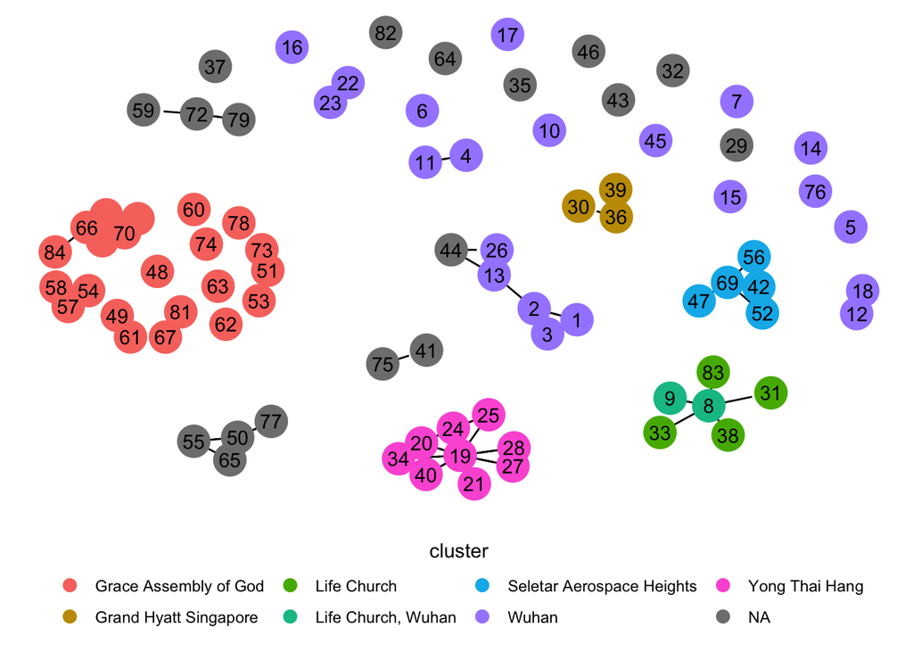

```r
cov_net=ggplot(n,aes(x = x, y = y, xend = xend, yend = yend))+
  geom_edges(aes(),subset(n,Related.cases!=""),linetype="solid")+
  geom_nodes(aes(x = x, y = y,color=cluster),size=8)+
  geom_text(aes(x = x, y = y,label=name),check_overlap = TRUE)+
  guides(colour = guide_legend(title.position="top",title.hjust = 0.5,override.aes = list(size=3)))+
  theme_bw()+
  theme(panel.grid = element_blank(),
        axis.title = element_blank(),
        axis.line = element_blank(),
        axis.text=element_blank(),
        axis.ticks = element_blank(),
        panel.border = element_blank(),
        legend.position = "bottom",
        legend.direction = "horizontal")


cov_net
```